# East Asian Demographic Crisis Dashboard

East Asian nations face unprecedented demographic challenges as plummeting birth rates and rapidly aging populations create a demographic time bomb that threatens economic growth and social stability.

**Key Aspects:**

- **Birth Rate Collapse**: Fertility rates have fallen far below replacement level
- **Aging Population**: Elderly populations are growing at unprecedented rates
- **Economic Implications**: These demographic shifts threaten economic growth and stability

**Data Source:** - World Bank Open Data (1974-2022)

**Countries Analyzed:** - Japan - South Korea - China

[interactive chart not shown]

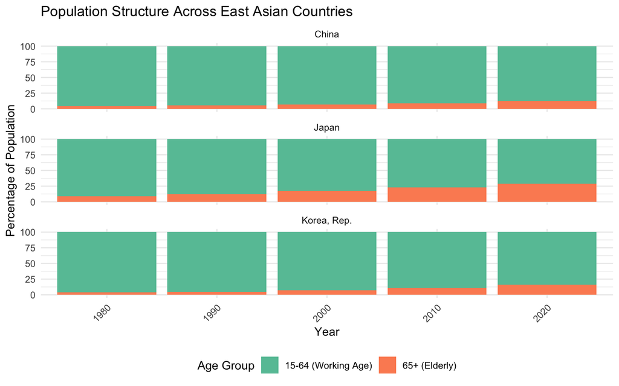

[interactive chart not shown]

| Country | Fertility Rate | Elderly Population (%) | Age Dependency Ratio |
| --- | --- | --- | --- |
| Japan | 1.33 | 28.92 | 69.89 |
| Korea, Rep. | 0.84 | 15.82 | 38.77 |
| China | 1.28 | 12.65 | 44.09 |

[interactive chart not shown]

This dashboard was created by Jared Leonard (C21468162) for CMPU4091 Visualizing Data module assignment.

The visualizations demonstrate the demographic crisis facing East Asian nations, characterized by:

- Ultra-low fertility rates far below replacement level
- Rapidly aging populations creating top-heavy demographic structures
- Economic consequences including labor shortages and unsustainable dependency ratios

The dashboard uses World Bank data to visualize these trends across China, Japan, and South Korea. The visualizations reveal the unprecedented speed of demographic change in these countries and the resulting challenges for economic growth and social stability.

**Key findings include:** - All three countries have fertility rates well below the replacement level of 2.1 births per woman - Japan leads with nearly 30% of its population over 65, but South Korea is aging at an even faster rate - The economic implications are severe, as shown in the demographic time bomb visualization - These demographic shifts happened in 3-4 decades in East Asia compared to a century in Western countries